# Frequency Estimation for a Sparsely Sampled Mira Light Curve

## The Gaussian process model

This is the proposed period estimation method in our work. Let $y_i$ be the magnitude of a variable star observed at time $t_i$ (in units of days) with uncertainty $\sigma_i$. The data set for this object, obtained as part of a time-series survey with $n$ epochs is $\{(t_i,y_i,\sigma_i)\}_{i=1}^n$.

Suppose the data $\{(t_i,y_i,\sigma_i)\}_{i=1}^n$ is modeled by
$$y_i = g(t_i) + \sigma_i\epsilon_i\,$$
where $g(t_i)$ is the light curve signal and the $\epsilon_i\sim N(0,1)$ is independent with other $\epsilon_j$’s.

The light curve signal $g(t_i)$ is decomposed into three parts
$$\begin{split}
g(t) & = m + q(t) + h(t)\\
& = m + \beta_1\cos(2\pi ft) + \beta_2\sin(2\pi ft) + h(t)\, ,
\end{split}$$
where $m$ is the long-run average magnitude, $q(t) = \beta_1\cos(2\pi ft) + \beta_2\sin(2\pi ft)$ with frequency $f$ is the exactly periodical signal, and $h(t)$ is the stochastic deviation from a constant mean magnitude, caused by the formation and destruction of dust in the cool atmospheres of Miras. To simplify notation, we define $\mathbf{b}_f(t) =(\cos(2\pi ft),\sin(2\pi ft))^T$, so that $q(t) = \mathbf{b}_f(t)^T\boldsymbol{\beta}$. The subscript $f$ in $\mathbf{b}_f(t)$ emphasizes that the basis is parameterized by the frequency $f$.

The term $h(t)$ is modeled by a Gaussian process with square exponential kernel $k_{\boldsymbol{\theta}} (t,t') = \theta_1^2\exp \left(-\frac{(t-t')^2}{2\theta_2^2}\right)$.
$$\begin{split}
& y_i | m,\boldsymbol{\beta}, g(t_i) \sim
\mathcal{N}(g(t_i), \sigma_i^2), \\
& g(t) = m + \mathbf{b}_f(t)^T\boldsymbol{\beta} + h(t), \\
& m \sim \mathcal{N}(m_0, \sigma_m^2),\
\boldsymbol{\beta} \sim \mathcal{N}(\mathbf{0},\sigma_b^2\mathbf{I} ),\\
& h(t)| \boldsymbol{\theta} \sim \mathcal{GP}(0,k_\boldsymbol{\theta} (t,t')),
\end{split}$$

## Example

Read in the fake light curve.

```r
library(varStar)
starObs = read.table("./mira_73762_wli31709_131.5.flc")
obsJD = starObs$V1
obsMag = starObs$V2
obsSigma = starObs$V3
head(starObs)
```

```
##          V1     V2    V3
## 1 1044.9293 20.433 0.061
## 2 1044.9376 20.488 0.067
## 3 1047.9503 20.521 0.073
## 4 1047.9621 20.604 0.064
## 5 1051.9394 20.535 0.105
## 6 1051.9868 20.666 0.112
```

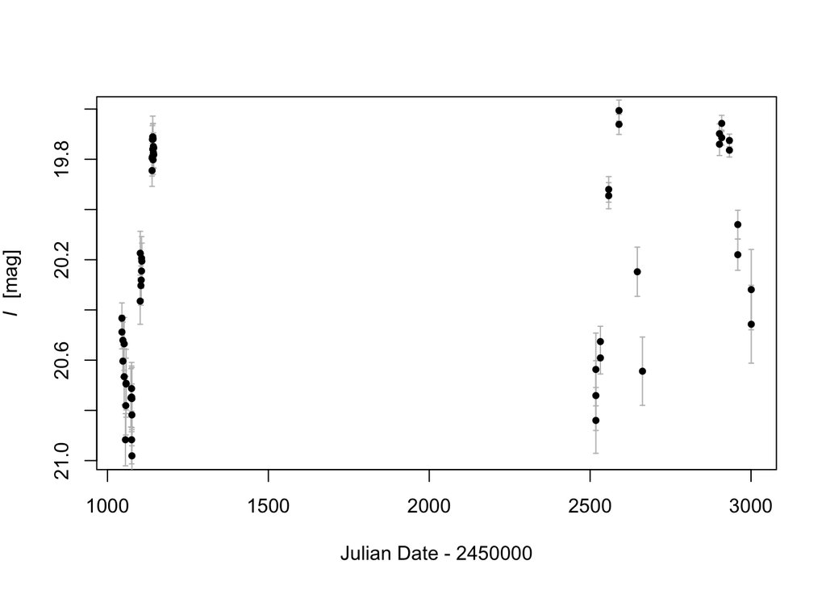

```r
plotStarObs(obsJD,obsMag,obsSigma)
```

Create an modeling object of class `simple_gpModel`. The `new()` function is used to create object, with additional parameters of Julian date, magnitude and observation sigma. The member function `freq_est()` is then called to produce the periodogram. The returned matrix `spc` has four columns. The first column is the frequency, the second column is the corresponding log-likelihood, and the third and fourth columns are the optimal $\theta_1$ and $\theta_2$.

```r
vsObj = new(simple_gpModel,
            obsJD, obsMag,obsSigma)
spc = vsObj$freq_est()
head(spc)
```

```
##         [,1]        [,2]          [,3]        [,4]
## [1,] 0.01000 39.60601391 -0.7782232943 3.587352869
## [2,] 0.00999 39.64776328 -0.7749598709 3.593884385
## [3,] 0.00998 39.68802543 -0.7713066092 3.600657131
## [4,] 0.00997 39.72629538 -0.7672863469 3.607578637
## [5,] 0.00996 39.76203604 -0.7629360593 3.614534328
## [6,] 0.00995 39.79468416 -0.7583091520 3.621386917
```

The first two columns are used to plot the periodogram. The true frequency of this generated light curve is 0.006236.

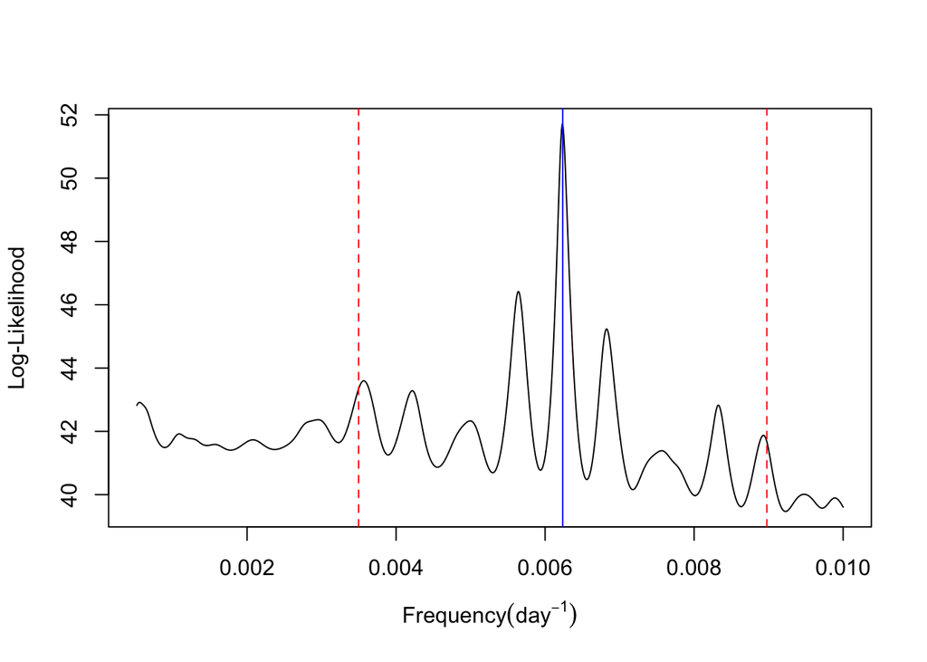

```r
plot(spc[,1],spc[,2],type="l", main="",
     xlab=expression(Frequency(day^-1)),
    ylab="Log-Likelihood")
f0 = 0.006236
abline(v = f0, col = "blue")
abline(v = f0+1/365, col = "red", lty = 2)
abline(v = f0-1/365, col = "red", lty = 2)
```